# intercept

Spy and stub network requests and responses.

> **Tip**: We recommend you read the [Network Requests](https://docs.cypress.io/guides/guides/network-requests) guide first.

> `cy.intercept()` is the successor to `cy.route()` as of Cypress 6.0.0. See Comparison to `cy.route`.

> All intercepts are automatically cleared before every test.

## Syntax

```javascript
// spying only
cy.intercept(url)
cy.intercept(method, url)
cy.intercept(routeMatcher)
```

See arguments url, method and routeMatcher

```javascript
// spying and response stubbing
cy.intercept(url, staticResponse)
cy.intercept(method, url, staticResponse)
cy.intercept(routeMatcher, staticResponse)
cy.intercept(url, routeMatcher, staticResponse)
```

See staticResponse argument

```javascript
// spying, dynamic stubbing, request modification, etc.
cy.intercept(url, routeHandler)
cy.intercept(method, url, routeHandler)
cy.intercept(routeMatcher, routeHandler)
cy.intercept(url, routeMatcher, routeHandler)
```

See routeHandler argument

### Usage

**Correct Usage**

```javascript
// spying
cy.intercept('/users/**')
cy.intercept('GET', '/users*')
cy.intercept({
  method: 'GET',
  url: '/users*',
  hostname: 'localhost',
})

// spying and response stubbing
cy.intercept('POST', '/users*', {
  statusCode: 201,
  body: {
    name: 'Peter Pan',
  },
})

// spying, dynamic stubbing, request modification, etc.
cy.intercept('/users*', { hostname: 'localhost' }, (req) => {
  /* do something with request and/or response */
})
```

### Arguments

#### **method** *(String)*

Match the route to a specific [HTTP method](https://developer.mozilla.org/en-US/docs/Web/HTTP/Methods) (`GET`, `POST`, `PUT`, etc).

> If no method is defined Cypress will match all requests by default.

#### **url** *(String, Glob, RegExp)*

Specify the URL to match. See Matching `url` for examples.

Alternatively, specify the URL via the `routeMatcher` argument (below).

#### **routeMatcher** *(`RouteMatcher`)*

`routeMatcher` is an object used to match the incoming HTTP requests with this intercepted route.

All properties are optional but all those that are set must match for the request to be intercepted. If a `string` is passed to any property, it will be glob-matched against the request using `Cypress.minimatch` with the `{ matchBase: true }` minimatch option applied.

| Option | Description |
| --- | --- |
| auth | HTTP Basic Authentication (`object` with keys `username` and `password`) |
| headers | HTTP request headers (`object`) |
| hostname | HTTP request hostname |
| https | `true`: only secure (https://) requests, `false`: only insecure (http://) requests |
| method | HTTP request method (matches any method by default) |
| middleware | `true`: match route first and in defined order, `false`: match route in reverse order (default) |
| path | HTTP request path after the hostname, including query parameters |
| pathname | Like `path`, but without query parameters |
| port | HTTP request port(s) (`number` or `Array`) |
| query | Parsed query string (`object`) |
| times | Maximum number of times to match (`number`) |
| url | Full HTTP request URL |

See examples below.

#### staticResponse (`StaticResponse`)

By passing in a `StaticResponse` as the last argument, you can statically define (stub) a response for matched requests. See `StaticResponse` object for the list of properties.

See Stubbing a response with a `StaticResponse` object for an example.

#### routeHandler (`Function`)

The `routeHandler` function is called whenever a request is matched, with the first argument being the request object. From inside the callback, you have access to the entire request-response where you can modify the outgoing request, send a response, access the real response, and more.

See "Intercepted requests" and Request/Response Modification with `routeHandler`.

### Yields

- `cy.intercept()` yields `null`.
- `cy.intercept()` can be aliased, but otherwise cannot be chained further.
- Waiting on an aliased `cy.intercept()` route using cy.wait() will yield an object that contains information about the matching request/response cycle. See Using the yielded object for examples of how to use this object.

## Examples

> `cy.intercept` can be used solely for spying: to passively listen for matching routes and apply aliases to them without manipulating the request or its response in any way. This alone is powerful as it allows you to wait for these requests, resulting in more reliable tests.

### Matching `url`

You can provide the exact URL to match or use pattern-matching to match many URLs at once, either with globs or with regex. See Glob Pattern Matching URLs.

```javascript
// match any request that exactly matches the URL
cy.intercept('https://prod.cypress.io/users')

// match any request that satisfies a glob pattern
cy.intercept('/users?_limit=*')

// match any request that satisfies a regex pattern
cy.intercept(/\/users\?_limit=(3|5)$/)
```

### Matching `method`

> If you don't pass in a `method` argument, then all HTTP methods (`GET`, `POST`, `PUT`, `PATCH`, `DELETE`, etc.) will match.

```javascript
cy.intercept('/users')
// matches this: GET http://localhost/users
// ...and this, too: POST http://localhost/users

cy.intercept('GET', '/users')
// matches this: GET http://localhost/users
// ...but not this: POST http://localhost/users
```

### Matching with RouteMatcher

Specifying a `method` and `url` to match can also be acheived by passing the `routeMatcher` object into `cy.intercept` instead:

```javascript
// These both yield the same result:
cy.intercept({ method: 'GET', url: '**/users' })
cy.intercept('GET', '**/users')
```

```javascript
// Match any type of request with the pathname `/search`
// and the query paramater 'q=some+terms'
cy.intercept({
  pathname: '/search',
  query: {
    q: 'some terms',
  },
}).as('searchForTerms')
```

```javascript
cy.intercept(
  {
    // this RegExp matches any URL beginning with
    // 'http://api.example.com/' and ending with '/edit' or '/save'
    url: /^http:\/\/api\.example\.com\/.*\/(edit|save)/,
    // matching requests must also contain this header
    headers: {
      'x-requested-with': 'exampleClient',
    },
  }
})
```

```javascript
// this example will cause 1 request to `/temporary-error`
// to receive a network error and subsequent requests will
// not match this `RouteMatcher`
cy.intercept('/temporary-error', { times: 1 }, { forceNetworkError: true })
```

### Pattern Matching

```javascript
// match updates to the `/users` endpoint using glob matching
cy.intercept({
  method: '+(PUT|PATCH)',
  url: '**/users/*',
})
// matches:
//   PUT /users/1
//   PATCH /users/1
//   doesn't match
//   GET /users
//   GET /users/1

// same as above, but using regex
cy.intercept({
  method: '/PUT|PATCH/',
  url: '**/users/*',
})
```

### Aliasing an intercepted route

While `cy.intercept` doesn't yield anything, you can chain `.as` to it to create an [alias](https://docs.cypress.io/guides/core-concepts/variables-and-aliases#Aliases) which can be used to wait on a request.

```javascript
cy.intercept('GET', '/users').as('getAllUsers')
cy.intercept('POST', '/users').as('createUser')
```

### Aliasing individual requests

Aliases can be set on a per-request basis by setting the `alias` property of the intercepted request. This is especially useful when intercepting GraphQL requests:

```javascript
cy.intercept('POST', '/graphql', (req) => {
  if (req.body.hasOwnProperty('query') && req.body.query.includes('mutation')) {
    req.alias = 'gqlMutation'
  }
})

// assert that a matching request has been made
cy.wait('@gqlMutation')
```

> For more guidance around aliasing requests with GraphQL, see [Working with GraphQL](https://docs.cypress.io/guides/testing-strategies/working-with-graphql)

### Waiting on a request

Use cy.wait() with aliasing an intercepted route to wait for the request/response cycle to complete.

#### With URL

```javascript
cy.intercept('http://example.com/settings').as('getSettings')

// once a request to get settings responds, 'cy.wait' will resolve
cy.wait('@getSettings')
```

#### With RouteMatcher

```javascript
cy.intercept({
  url: 'http://example.com/search*',
  query: { q: 'expected terms' },
}).as('search')

// once any type of request to search with a querystring
// containing 'q=expected+terms' responds, 'cy.wait' will resolve
cy.wait('@search')
```

#### Using the yielded object

Using cy.wait() on a `cy.intercept()` route alias yields an interception object which represents the request/response cycle:

```javascript
cy.wait('@someRoute').then((interception) => {
  // 'interception' is an object with properties
  // 'id', 'request' and 'response'
})
```

You can chain `.its()` and `.should()` to assert against request/response cycles:

```javascript
// assert that a request to this route
// was made with a body that included 'user'
cy.wait('@someRoute').its('request.body').should('include', 'user')

// assert that a request to this route
// received a response with HTTP status 500
cy.wait('@someRoute').its('response.statusCode').should('eq', 500)

// assert that a request to this route
// received a response body that includes 'id'
cy.wait('@someRoute').its('response.body').should('include', 'id')
```

#### Waiting on errors

You can use cy.wait() to wait on requests that end with network errors:

```javascript
cy.intercept('GET', '/should-err', { forceNetworkError: true }).as('err')

// assert that this request happened
// and that it ended in an error
cy.wait('@err').should('have.property', 'error')
```

### Stubbing a response

#### With a string

```javascript
// requests to '/update' will be fulfilled
// with a body of "success"
cy.intercept('/update', 'success')
```

#### With a fixture

```javascript
// requests to '/users.json' will be fulfilled
// with the contents of the "users.json" fixture
cy.intercept('/users.json', { fixture: 'users.json' })
```

#### With a `StaticResponse` object

A `StaticResponse` object represents a response to an HTTP request, and can be used to stub routes:

```javascript
const staticResponse = {
  /* some StaticResponse properties here... */
}

cy.intercept('/projects', staticResponse)
```

Stub a response with a JSON body:

```javascript
cy.intercept('/projects', {
  body: [{ projectId: '1' }, { projectId: '2' }],
})
```

Stub headers, status code, and body all at once:

```javascript
cy.intercept('/not-found', {
  statusCode: 404,
  body: '404 Not Found!',
  headers: {
    'x-not-found': 'true',
  },
})
```

Stub response with a fixture that is read as a Buffer:

```javascript
cy.intercept('/not-found', {
  fixture: 'media/gif.mp4,null',
})
```

See also `StaticResponse` object.

### Using the **`routeHandler`** function

By specifying a `routeHandler` function as the last argument to `cy.intercept`, you'll have access to the entire request-response session, enabling you to modify the outgoing request, manipulate the real response, make assertions, etc.

The `routeHandler` takes the incoming HTTP request (`IncomingHTTPRequest`) as the first argument.

```javascript
cy.intercept('/users*', (req) => {
  /* do something with request and/or response */
})
```

> Throughout these examples we will refer to the incoming HTTP request as `req`. Those of you with [Express.js](https://expressjs.com/) [middleware](https://expressjs.com/en/guide/writing-middleware.html) experience should be familiar with this syntax.

#### Asserting on a request

```javascript
cy.intercept('POST', '/organization', (req) => {
  expect(req.body).to.include('Acme Company')
})
```

#### Modifying an outgoing request

You can use the request handler callback to modify the intercepted request object before it is sent.

```javascript
// set the request body to something different
// before it's sent to the destination
cy.intercept('POST', '/login', (req) => {
  req.body = 'username=janelane&password=secret123'
})

// dynamically set the alias
cy.intercept('POST', '/login', (req) => {
  req.alias = 'login'
})
```

#### Adding a header to an outgoing request

You can add a header to an outgoing request, or modify an existing header

```javascript
cy.intercept('/req-headers', (req) => {
  req.headers['x-custom-headers'] = 'added by cy.intercept'
})
```

**Note:** the new header will NOT be shown in the browser's Network tab, as the request has already left the browser. You can still confirm the header was added by waiting on the intercept as shown below:

#### Waiting on the intercept

```javascript
cy.intercept('/req-headers', (req) => {
  req.headers['x-custom-headers'] = 'added by cy.intercept'
}).as('headers')

// the application makes the call ...
// confirm the custom header was added
cy.wait('@headers')
  .its('request.headers')
  .should('have.property', 'x-custom-headers', 'added by cy.intercept')
```

#### Add, modify or delete a header to all outgoing requests

You can add, modify or delete a header to all outgoing requests using a `beforeEach()` in the `cypress/support/index.js` file

```javascript
// cypress/support/index.ts

beforeEach(() => {
  cy.intercept(
    { url: 'http://localhost:3001/**', middleware: true },
    // Delete 'if-none-match' header from all outgoing requests
    (req) => delete req.headers['if-none-match']
  )
})
```

#### Dynamically stubbing a response

You can use the `req.reply()` function to dynamically control the response to a request.

```javascript
cy.intercept('/billing', (req) => {
  // functions on 'req' can be used to
  // dynamically respond to a request here

  // send the request to the destination server
  req.reply()

  // respond to the request with a JSON object
  req.reply({ plan: 'starter' })

  // send the request to the destination server
  // and intercept the response
  req.continue((res) => {
    // 'res' represents the real destination's response
    // See "Intercepting a response" for more details and examples
  })
})
```

See "Intercepted requests" for more information on the `req` object and its properties and methods.

#### Returning a Promise

If a Promise is returned from the route callback, it will be awaited before continuing with the request.

```javascript
cy.intercept('POST', '/login', (req) => {
  // you could asynchronously fetch test data...
  return getLoginCredentials().then((credentials) => {
    // ...and then, use it to supplement the outgoing request
    req.headers['authorization'] = credentials
  })
})
```

#### Passing a request to the next request handler

If `req.reply()` or `req.continue()` is not explicitly called inside of a request handler, requests will pass to the next request handler until none are left.

```javascript
// you could have a top-level middleware handler that
// sets an auth token on all requests
// but remember setting `middleware: true` will
// cause this to always be called first
cy.intercept('http://api.company.com/', { middleware: true }, (req) => {
  req.headers['authorization'] = `token ${token}`
})

// and then have another handler that
// more narrowly asserts on certain requests
cy.intercept('POST', 'http://api.company.com/widgets', (req) => {
  expect(req.body).to.include('analytics')
})

// a POST request to http://api.company.com/widgets would hit both
// of those callbacks, middleware first, then the request would be
// sent out with the modified request headers to the
// real destination
```

### Intercepting a response

Inside of a callback passed to `req.continue()`, you can access the destination server's real response.

```javascript
cy.intercept('/integrations', (req) => {
  // req.continue() with a callback will send the request to
  // the destination server
  req.continue((res) => {
    // 'res' represents the real destination response
    // you can manipulate 'res' before it's sent to the browser
  })
})
```

See "Intercepted responses" for more information on the `res` object. See "Controlling the outbound request with `req.continue()`" for more information about `req.continue()`.

#### Asserting on a response

```javascript
cy.intercept('/projects/2', (req) => {
  req.continue((res) => {
    expect(res.body).to.include('My Project')
  })
})
```

#### Returning a Promise

If a Promise is returned from the route callback, it will be awaited before sending the response to the browser.

```javascript
cy.intercept('/users', (req) => {
  req.continue((res) => {
    // the response will not be sent to the browser until
    // 'waitForSomething()' resolves
    return waitForSomething()
  })
})
```

#### Throttle or delay response all incoming responses

You can throttle or delay all incoming responses using a `beforeEach()` in the `cypress/support/index.js` file

```javascript
// cypress/support/index.ts

// Throttle API responses to simulate real-world conditions
cy.intercept(
  {
    url: 'http://localhost:3001/**',
    middleware: true,
  },
  (req) => {
    req.on('response', (res) => {
      // Throttle the response to 1 Mbps to simulate a
      // mobile 3G connection
      res.setThrottle(1000)
    })
  }
)
```

### Request/Response Modification with `routeHandler`

Specify `routeHandler` as the last argument to modify the outgoing request, stub a response, make assertions, etc.

If a function is passed as the `routeHandler`, it will be called with the intercepted HTTP request:

```javascript
cy.intercept('/api', (req) => {
  // do something with the intercepted request
})
```

From here, you can do several things with the intercepted request:

- modify and make assertions on the request like its body, headers, URL, method, etc. (example)
- stub out the response without interacting with a real back-end (example
- pass the request through to its destination and modify or make assertions on the real response on its way back (example)
- attach listeners to various events on the request (example)

#### Asserting on a request

You can use the request handler callback to make an assertion on the intercepted request object before it is sent.

```javascript
// match requests to create a user
cy.intercept('POST', '/users', (req) => {
  // make an assertion on the payload contents
  expect(req.body).to.include('Peter Pan')
})
```

#### Controlling the outgoing request

The outgoing request, including its body, headers, etc., can be modified before it's sent.

```javascript
// modify the request body before it's sent to its destination
cy.intercept('POST', '/users', (req) => {
  req.body = {
    name: 'Peter Pan',
  }
})

// add a header to an outgoing request
cy.intercept('POST', '/users', (req) => {
  req.headers['x-custom-header'] = 'added by cy.intercept'
})

// modify an existing header
cy.intercept('POST', '/users', (req) => {
  req.headers['authorization'] = 'Basic YWxhZGRpbjpvcGVuc2VzYW1l'
})
```

#### Verifying the request modification

```javascript
cy.intercept('POST', '/users', (req) => {
  req.headers['x-custom-header'] = 'added by cy.intercept'
}).as('createUser')

cy.get('button.save').click()
// you can see the headers in the console output by selecting
// this line in the command log:
cy.wait('@createUser')
  // ...or make an assertion:
  .its('request.headers')
  .should('have.property', 'x-custom-header', 'added by cy.intercept')
```

> The request modification cannot be verified by inspecting the browser's network traffic (for example, in Chrome DevTools), since the browser logs network traffic *before* Cypress can intercept it.

> `cy.intercept()` cannot be debugged using `cy.request()`! Cypress only intercepts requests made by your front-end application.

#### Controlling the response

The intercepted request passed to the route handler (hereafter referred to as `req`, though you can use any name) contains methods to dynamically control the response to a request:

- `req.reply()` - stub out a response requiring no dependency on a real back-end
- `req.continue()` - modify or make assertions on the real response
- `req.destroy()` - destroy the request and respond with a network error
- `req.redirect()` - respond to the request with a redirect to a specified location
- `req.on()` - modify the response by attaching to events

Stubbing out a response (`req.reply()`):

`req.reply()` takes a `StaticResponse` object as the first argument:

```javascript
// stub out the response without interacting with a real back-end
cy.intercept('POST', '/users', (req) => {
  req.reply({
    headers: {
      Set-Cookie: 'newUserName=Peter Pan;'
    },
    statusCode: 201,
    body: {
      name: 'Peter Pan'
    },
    delay: 10, // milliseconds
    throttleKbps: 1000, // to simulate a 3G connection
    forceNetworkError: false // default
  })
})

// stub out a response body using a fixture
cy.intercept('GET', '/users', (req) => {
  req.reply({
    statusCode: 200, // default
    fixture: 'users.json'
  })
})
```

See `StaticResponse` objects below for more information.

The `reply` method also supports shorthand to avoid having to specify a `StaticResponse` object:

```javascript
// equivalent to `req.reply({ body })`
req.reply(body)

// equivalent to `req.reply({ body, headers })`
req.reply(body, headers)

// equivalent to `req.reply({ statusCode, body, headers})`
req.reply(statusCode, body, headers)
```

> Note: Calling `reply()` will end the request phase and stop the request from propagating to the next matching request handler in line. See Interception Lifecycle.

See also Providing a stub response with `req.reply()`

Modifying the real response (`continue`):

The `continue` method accepts a function which is passed an object representing the real response being intercepted on its way back to the client (your front-end application).

```javascript
// pass the request through and make an assertion on
// the real response
cy.intercept('POST', '/users', (req) => {
  req.continue((res) => {
    expect(res.body).to.include('Peter Pan')
  })
})
```

See also Controlling the outbound request with `req.continue()`

Responding with a network error (`destroy`):

```javascript
// dynamically destroy the request and
// respond with a network error
cy.intercept('POST', '/users', (req) => {
  if (mustDestroy(req)) {
    req.destroy()
  }

  function mustDestroy(req) {
    // code that determines whether to force a network error
    // based on the contents of `req`
  }
})
```

Responding with a new location (`redirect`):

```javascript
// respond to this request with a redirect to a new 'location'
cy.intercept('GET', '/users', (req) => {
  // statusCode defaults to `302`
  req.redirect('/customers', 301)
})
```

Responding by listening to events (`on`):

```javascript
cy.intercept('GET', '/users', (req) => {
  req.on('before:response', (res) => {
    // do something when the `before:response` event is triggered
  })
})
cy.intercept('POST', '/users', (req) => {
  req.on('response', (res) => {
    // do something when the `response` event is triggered
  })
})
```

See example for throttling a response See more examples of events

#### Returning a Promise

If a Promise is returned from the route callback, it will be awaited before continuing with the request.

```javascript
cy.intercept('POST', '/users', (req) => {
  // asynchronously fetch test data
  return getAuthToken().then((token) => {
    // ...and apply it to the outgoing request
    req.headers['Authorization'] = `Basic ${token}`
  })
})

cy.intercept('POST', '/users', (req) => {
  req.continue((res) => {
    // the response will not be sent to the browser until
    // `waitForSomething()` resolves:
    return waitForSomething()
  })
})
```

#### Stubbing a response with a string

```javascript
// requests to create a user will be fulfilled
// with a body of 'success'
cy.intercept('POST', '/users', 'success')
// { body: 'sucess' }
```

## Intercepted requests

If a function is passed as the handler for a `cy.intercept()`, it will be called with the first argument being an object that represents the intercepted HTTP request:

```javascript
cy.intercept('/api', (req) => {
  // `req` represents the intercepted HTTP request
})
```

From here, you can do several things with the intercepted request:

- you can modify and assert on the request's properties (body, headers, URL, method...)
- the request can be sent to the real upstream server
  - optionally, you can intercept the response from this
- a response can be provided to stub out the request
- listeners can be attached to various events on the request

### Request object properties

The request object (`req`) has several properties from the HTTP request itself. All of the following properties on `req` can be modified except for `httpVersion`:

```
{
  /**
   * The body of the request.
   * If a JSON Content-Type was used and the body was valid JSON,
   * this will be an object.
   * If the body was binary content, this will be a buffer.
   */
  body: string | object | any
  /**
   * The headers of the request.
   */
  headers: { [key: string]: string }
  /**
   * Request HTTP method (GET, POST, ...).
   */
  method: string
  /**
   * Request URL.
   */
  url: string
  /**
   * URL query string as object.
   */
  query: Record<string, string|number>
  /**
   * The HTTP version used in the request. Read only.
   */
  httpVersion: string
}
```

`req` also has some optional properties which can be set to control Cypress-specific behavior:

```
{
  /**
   * If provided, the number of milliseconds before an upstream
   * response to this request will time out and cause an error.
   * By default, `responseTimeout` from config is used.
   */
  responseTimeout?: number
  /**
   * Set if redirects should be followed when this request is made.
   * By default, requests will not follow redirects before
   * yielding the response (the 3xx redirect is yielded).
   */
  followRedirect?: boolean
  /**
   * If set, `cy.wait` can be used to await the request/response
   * cycle to complete for this request via `cy.wait('@alias')`.
   */
  alias?: string
}
```

Any modifications to the properties of `req` will be persisted to other request handlers, and finally merged into the actual outbound HTTP request.

### Controlling the outbound request with `req.continue()`

Calling `req.continue()` without any argument will cause the request to be sent outgoing, and the response will be returned to the browser after any other listeners have been called. For example, the following code modifies a `POST` request and then sends it to the upstream server:

```javascript
cy.intercept('POST', '/submitStory', (req) => {
  req.body.storyName = 'some name'
  // send the modified request and skip any other
  // matching request handlers
  req.continue()
})
```

If a function is passed to `req.continue()`, the request will be sent to the real upstream server, and the callback will be called with the response once the response is fully received from the server. See "Intercepted responses"

Note: calling `req.continue()` will stop the request from propagating to the next matching request handler in line. See "Interception lifecycle" for more information.

### Providing a stub response with `req.reply()`

The `req.reply()` function can be used to send a stub response for an intercepted request. By passing a string, object, or `StaticResponse` to `req.reply()`, the request can be preventing from reaching the destination server.

For example, the following code stubs out a JSON response from a request interceptor:

```javascript
cy.intercept('/billing', (req) => {
  // dynamically get billing plan name at request-time
  const planName = getPlanName()
  // this object will automatically be JSON.stringified and
  // sent as the response
  req.reply({ plan: planName })
})
```

Instead of passing a plain object or string to `req.reply()`, you can also pass a `StaticResponse` object. With a `StaticResponse`, you can force a network error, delay/throttle the response, send a fixture, and more.

For example, the following code serves a dynamically chosen fixture with a delay of 500ms:

```javascript
cy.intercept('/api/users/*', async (req) => {
  // asynchronously retrieve fixture filename at request-time
  const fixtureFilename = await getFixtureFilenameForUrl(req.url)
  req.reply({
    fixture: fixtureFilename,
    delay: 500,
  })
})
```

See the `StaticResponse` documentation for more information on stubbing responses in this manner.

#### `req.reply()` shorthand

`req.reply()` also supports shorthand, similar to `res.send()`, to avoid having to specify a `StaticResponse` object:

```javascript
// equivalent to `req.reply({ body })`
req.reply(body)

// equivalent to `req.reply({ body, headers })`
req.reply(body, headers)

// equivalent to `req.reply({ statusCode, body, headers})`
req.reply(statusCode, body, headers)
```

#### Convenience functions

There are also two convenience functions available on `req`:

```
{
  /**
   * Destroy the request and respond with a network error.
   */
  destroy(): void
  /**
   * Respond to this request with a redirect to a new 'location'.
   * @param statusCode HTTP status code to redirect with. Default: 302
   */
  redirect(location: string, statusCode?: number): void
}
```

See examples in the Controlling the response section

Note: calling `req.reply()` will end the request phase and stop the request from propagating to the next matching request handler in line. See "Interception lifecycle" for more information.

### Request events

For advanced use, several events are available on `req`, that represent different stages of the Interception lifecycle.

By calling `req.on`, you can subscribe to different events:

```javascript
cy.intercept('/shop', (req) => {
  req.on('before:response', (res) => {
    /**
     * Emitted before `response` and before any `req.continue`
     * handlers. Modifications to `res` will be applied to the
     * incoming response. If a promise is returned, it will be
     * awaited before processing other event handlers.
     */
  })

  req.on('response', (res) => {
    /**
     * Emitted after `before:response` and after any
     * `req.continue` handlers - before the response is sent
     * to the browser. Modifications to `res` will be applied
     * to the incoming response. If a promise is returned, it
     * will be awaited before processing other event handlers.
     */
  })

  req.on('after:response', (res) => {
    /**
     * Emitted once the response to a request has finished
     * sending to the browser. Modifications to `res` have no
     * impact. If a promise is returned, it will be awaited
     * before processing other event handlers.
     */
  })
})
```

See "Intercepted responses" for more details on the `res` object yielded by `before:response` and `response`. See "Interception lifecycle" for more details on request ordering.

## Intercepted responses

The response can be intercepted in two ways:

- by passing a callback to `req.continue()` within a request handler
- by listening for the `before:response` or `response` request events (see "Request events")

The response object, `res`, will be passed as the first argument to the handler function:

```javascript
cy.intercept('/url', (req) => {
  req.on('before:response', (res) => {
    // this will be called before any `req.continue` or
    // `response` handlers
  })

  req.continue((res) => {
    // this will be called after all `before:response`
    // handlers and before any `response` handlers
    // by calling `req.continue`, we signal that this
    // request handler will be the last one, and that
    // the request should be sent outgoing at this point.
    // for that reason, there can only be one
    // `req.continue` handler per request.
  })

  req.on('response', (res) => {
    // this will be called after all `before:response`
    // handlers and after the `req.continue` handler
    // but before the response is sent to the browser
  })
})
```

### Response object properties

The response object (`res`) yielded to response handlers has several properties from the HTTP response itself. All of the following properties on `res` can be modified:

| Property | Description |
| --- | --- |
| body | response body (`object`, `string`, `ArrayBuffer`) |
| headers | response headers (`object`) |
| statusCode | response status code (`number`) |
| statusMessage | response status message (`string`) |

**Note about `body`:** If the response header contains `Content-Type: application/json` and the body contains valid JSON, this will be an `object`. And if the body contains binary content, this will be a buffer.

`res` also has some optional properties which can be set to control Cypress-specific behavior:

| Property | Description |
| --- | --- |
| throttleKbps | Maximum data transfer rate of the response (kilobits/second) |
| delay | Minimum network latency or delay to add to the response time (milliseconds) |

Any modifications to the properties of `res` will be persisted to other response handlers, and finally merged into the actual incoming HTTP response.

### Ending the response with `res.send()`

To end the response phase of the request, call `res.send()`. Optionally, you can pass a `StaticResponse` to `res.send()`, to be merged with the actual response.

When `res.send()` is called, the response phase will end immediately and no other response handlers will be called for the current request. Here is an example of how `res.send()` could be used:

```javascript
cy.intercept('/notification', (req) => {
  req.continue((res) => {
    if (res.body.status === 'failed') {
      // sends a fixture body instead of the existing 'res.body'
      res.send({ fixture: 'success.json' })
    }
  })
})
```

See the `StaticResponse` documentation for more information on the format.

#### `res.send()` shorthand

`res.send()` also supports shorthand, similar to `req.reply()`, to avoid having to specify a `StaticResponse` object:

```javascript
// equivalent to `res.send({ body })`
res.send(body)

// equivalent to `res.send({ body, headers })`
res.send(body, headers)

// equivalent to `res.send({ statusCode, body, headers})`
res.send(statusCode, body, headers)
```

#### Convenience functions

There are also two convenience functions available on `res`:

```
{
  /**
   * Wait for 'delay' milliseconds before sending the
   * response to the client.
   */
  setDelay: (delay: number) => IncomingHttpResponse
  /**
   * Serve the response at 'throttleKbps' kilobytes per second.
   */
  setThrottle: (throttleKbps: number) => IncomingHttpResponse
}
```

Note: calling `res.send()` will end the response phase and stop the response from propagating to the next matching response handler in line. See "Interception lifecycle" for more information.

## `StaticResponse` objects

A `StaticResponse` represents a statically defined response (stub).

The following properties are available on `StaticResponse`.

| Option | Description |
| --- | --- |
| statusCode | HTTP response status code |
| headers | HTTP response headers |
| body | Serve a static response body (`object`, `string`, `ArrayBuffer`) (when `fixture` is omitted). |
| fixture | Serve a fixture as the HTTP response body (allowed when `body` is omitted). Read the contents with an encoding other than the default for the file type, pass the fixture like `path,encoding`. |
| forceNetworkError | Force an error by destroying the browser connection |
| delay | Minimum network latency or delay to add to the response time (milliseconds) |
| throttleKbps | Maximum data transfer rate of the response (kilobits/second) |

**Note:** All properties are optional.

You can supply a `StaticResponse` to Cypress in 3 ways:

- To `cy.intercept()` as `an argument`, to stub a response to a route: `cy.intercept('/url', staticResponse)`
- To `req.reply()`, to stub a response from a request handler: `req.reply(staticResponse)`
- To `res.send()`, to stub a response from a response handler: `res.send(staticResponse)`

See "Stubbing a response with a `StaticResponse` object" for examples of stubbing with `cy.intercept()`.

## Interception lifecycle

The lifecycle of a `cy.intercept()` interception begins when an HTTP request is sent from your app that matches one or more registered `cy.intercept()` routes. From there, each interception has two phases: request and response.

`cy.intercept()` routes are matched in reverse order of definition, except for routes which are defined with `{ middleware: true }`, which always run first. This allows you to override existing `cy.intercept()` declarations by defining an overlapping `cy.intercept()`:

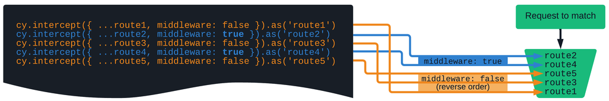

### Request phase

The following steps are used to handle the request phase.

1. Start with the first matching route according to the above algorithm (middleware first, followed by handlers in reverse order).
2. Was a handler (body, `StaticResponse`, or function) supplied to `cy.intercept()`? If not, continue to step 7.
3. If the handler was a body or `StaticResponse`, immediately end the request with that response.
4. If the handler was a function, call the function with `req`, the incoming request, as the first argument. See "Intercepted requests" for more information on the `req` object.
   - If `req.reply()` is called, immediately end the request phase with the provided response. See "Providing a stub response with `req.reply()`".
   - If `req.continue()` is called, immediately end the request phase, and send the request to the destination server. If a callback is provided to `req.continue()`, it will be called during the response phase
5. If the handler returned a Promise, wait for the Promise to resolve.
6. Merge any modifications to the request object with the real request.
7. If there is another matching `cy.intercept()`, return to step 2 and continue following steps with that route.
8. Send the request outgoing to the destination server and end the request phase. The response phase will begin once a response is received.

### Response phase

Once the HTTP response is received from the upstream server, the following steps are applied:

1. Get a list of registered `before:response` event listeners.
2. For each `before:response` listener (if any), call it with the `res` object.
   - If `res.send()` is called, end the response phase and merge any passed arguments with the response.
   - If a Promise is returned, await it. Merge any modified response properties with the real response.
3. If a `req.continue()` with callback is declared for this route, call the callback with the `res` object.
   - If `res.send()` is called, end the response phase and merge any passed arguments with the response.
   - If a Promise is returned, await it. Merge any modified response properties with the real response.
4. Get a list of registered `response` event listeners.
5. For each `response` listener (if any), call it with the `res` object.
   - If `res.send()` is called, end the response phase and merge any passed arguments with the response.
   - If a Promise is returned, await it. Merge any modified response properties with the real response.
6. Send the response to the browser.
7. Once the response is complete, get a list of registered `after:response` event listeners.
8. For each `after:response` listener (if any), call it with the `res` object (minus `res.send`)
   - If a Promise is returned, await it.
9. End the response phase.

## Glob Pattern Matching URLs

When matching a URL, providing an exact URL to match can be too restrictive. For example, what if you wanted to run your tests on a different host?

```javascript
// match any request that exactly matches the URL
cy.intercept('https://prod.cypress.io/users')
// matches this: https://prod.cypress.io/users
// ...but not this: https://staging.cypress.io/users
// ...or this: http://localhost/users
```

Glob pattern matching provides the necessary flexibility:

```javascript
cy.intercept('/users')
// matches all of these:
//   https://prod.cypress.io/users
//   https://staging.cypress.io/users
//   http://localhost/users

cy.intercept('/users?_limit=+(3|5)')
// matches all of these:
//   https://prod.cypress.io/users?_limit=3
//   http://localhost/users?_limit=5
```

### Cypress.minimatch

Under the hood, `cy.intercept` uses the minimatch library with the `{ matchBase: true }` option applied for glob matching and provides access to it via the `Cypress` global. This enables you to test your pattern in your spec or in the Test Runner browser console.

You can invoke the `Cypress.minimatch` with just two arguments - the URL (`string`) and the pattern (`string`), respectively - and if it yields `true`, then you have a match!

```javascript
expect(
  Cypress.minimatch('http://localhost/users?_limit=3', '**/users?_limit=+(3|5)')
).to.be.true
expect(
  Cypress.minimatch('http://localhost/users?_limit=5', '/users?_limit=+(3|5)', {
    matchBase: true,
  })
).to.be.true
expect(
  Cypress.minimatch('http://localhost/users?_limit=7', '**/users?_limit=+(3|5)')
).to.be.false
```

#### minimatch options

You can also pass in options (`object`) as the third argument, one of which is `debug` which if set to `true`, will yield verbose output that could help you understand why your pattern isn't working as you expect:

```javascript
Cypress.minimatch('http://localhost/users?_limit=3', '**/users?_limit=+(3|5)', {
  debug: true,
})
// true (plus debug messages)
```

## Comparison to `cy.route()`

Unlike cy.route(), `cy.intercept()`:

- can intercept all types of network requests including Fetch API, page loads, XMLHttpRequests, resource loads, etc.
- does not require calling cy.server() before use - in fact, `cy.server()` does not influence `cy.intercept()` at all.
- does not have method set to `GET` by default, but intercepts `*` methods.

## `cy.intercept()` and request caching

`cy.intercept()` intercepts requests at the network layer. This can cause confusion when trying to intercept a request that has already been cached by the browser. If a request is served from the browser cache, it will never hit the network layer, and `cy.intercept()` will never fire.

To see if this is affecting your app, check the Developer Tools. In the following example, all of the requests circled in red have been served from cache, and will not send an HTTP request. Thus, they cannot be intercepted by `cy.intercept()`:

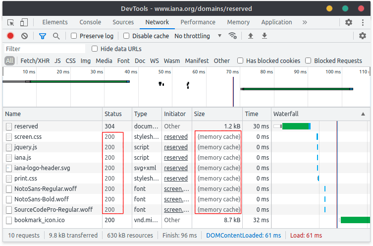

If you would like to intercept resources that normally send cache headers, here are some workarounds:

- Turn off cache headers on your development server when in testing mode.
- Disable caching on responses by adding a top-level `cy.intercept()` that removes cache headers from desired requests. For example:

  ```
  beforeEach(() => {
    cy.intercept(
      'https://api.example.com/**/*',
      { middleware: true },
      (req) => {
        req.on('before:response', (res) => {
          // force all API responses to not be cached
          res.headers['cache-control'] = 'no-store'
        })
      }
    )
  })
  ```

- Chromium-family browsers only: Use `remote:debugger:protocol` to disable cache entirely. For more information, see [this comment on issue #14459](https://github.com/cypress-io/cypress/issues/14459#issuecomment-768616195)

## Command Log

```javascript
cy.intercept('/accounts*').as('accountsGet')
cy.intercept('/company', { companyId: 1 }).as('companyGet')
cy.intercept('/teams*', [{ teamId: 2 }]).as('teamsGet')
```

Whenever you create `cy.intercept()` rules, Cypress will display a new Instrument Panel called *Routes*. It will list the routing table in the Instrument Panel, including the `method`, `RouteMatcher`, if the route is stubbed, any alias, and number of matched requests:

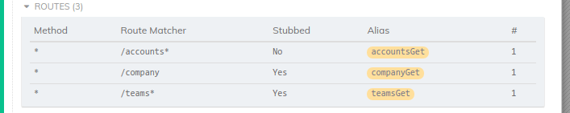

When HTTP requests are made, Cypress will log them in the Command Log and indicate whether they matched a `cy.intercept()` by the presence of a yellow badge on the right hand side:

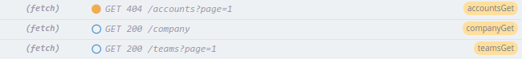

The circular indicator is filled if the request went to the destination server, but unfilled if the request was stubbed with a response.

Clicking on a request that matched a `cy.intercept()` will print additional information about the request and response to the console:

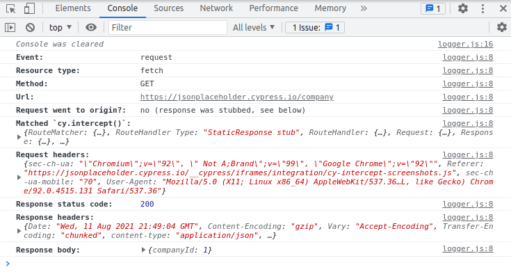

[Read more about request logging in Cypress.](https://docs.cypress.io/guides/guides/network-requests#Command-Log)

## History

[output not shown]

## See also

- `.as()`
- `cy.wait()`
- [Network Requests Guide](https://docs.cypress.io/guides/guides/network-requests)
- [Cypress Example Recipes](https://github.com/cypress-io/cypress-example-recipes#stubbing-and-spying)
- [Kitchen Sink Examples](https://github.com/cypress-io/cypress-example-kitchensink/blob/master/cypress/integration/2-advanced-examples/network_requests.spec.js)
- [Migrating `cy.route()` to `cy.intercept()`](https://docs.cypress.io/guides/references/migration-guide#Migrating-cy-route-to-cy-intercept)
- [Smart GraphQL Stubbing in Cypress](https://glebbahmutov.com/blog/smart-graphql-stubbing/) blog post
- [How cy.intercept works](https://slides.com/bahmutov/how-cy-intercept-works)
- [Cypress `cy.intercept()` Problems](https://glebbahmutov.com/blog/cypress-intercept-problems/)

© 2017 Cypress.io  
Licensed under the MIT License.  
https://docs.cypress.io/api/commands/intercept